# D17129187_PSI_CA2

```r
#tolerance
1/vif(base_model_nooutlier)
```

```
##    height       age
## 0.9943925 0.9943925
```

**train sex model No Outlier**

```r
sex_model_nooutlier <- lm(weight ~ height + age + sex, data = training_data_nooutlier)
summary(sex_model_nooutlier)
```

```
##
## Call:
## lm(formula = weight ~ height + age + sex, data = training_data_nooutlier)
##
## Residuals:
##     Min      1Q  Median      3Q     Max
## -21.099  -7.585  -1.615   6.256  32.544
##
## Coefficients:
##              Estimate Std. Error t value Pr(>|t|)
## (Intercept) -14.17517   20.64138  -0.687 0.493289
## height        0.44920    0.12506   3.592 0.000442 ***
## age           0.16209    0.07548   2.148 0.033327 *
## sexMale       9.56382    2.57200   3.718 0.000281 ***
## ---
## Signif. codes:  0 '***' 0.001 '**' 0.01 '*' 0.05 '.' 0.1 ' ' 1
##
## Residual standard error: 11.22 on 153 degrees of freedom
##   (32 observations deleted due to missingness)
## Multiple R-squared:  0.3956, Adjusted R-squared:  0.3838
## F-statistic: 33.38 on 3 and 153 DF,  p-value: < 2.2e-16
```

**test sex model No Outlier**

```r
test_sex_model_nooutlier <- predict(sex_model_nooutlier, test_data)
difference__sex_nooutlier <-   test_data$weight - test_sex_model_nooutlier

# Calculate RMSE
sqrt(mean(difference__sex_nooutlier^2, na.rm = T))
```

```
## [1] 11.73818
```

** Check for new outliers **

```r
sm_no_df <- as.data.frame(sex_model_nooutlier$residuals)
names(sm_no_df) <- 'residuals'
sex_model_no_outliers <- sm_no_df %>%
  filter(scale(residuals) >3.29 | scale(residuals) < -3.29)

#count them using dplyr summarize
num_sex_model__no_outliers<-sex_model_no_outliers %>% summarize(count=n())
fullcount_sex_model_no<-sm_no_df %>% summarize(count=n())

# % outside range
round((num_sex_model__no_outliers/fullcount_sex_model_no)*100, digits=2)
```

```
##   count
## 1     0
```

**Diagnostic Plots Sex Model No Outlier**

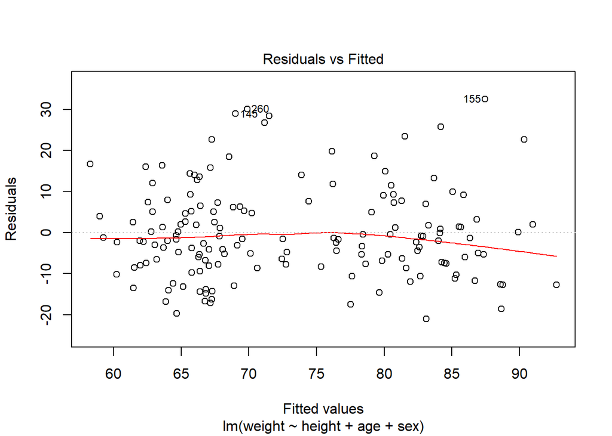

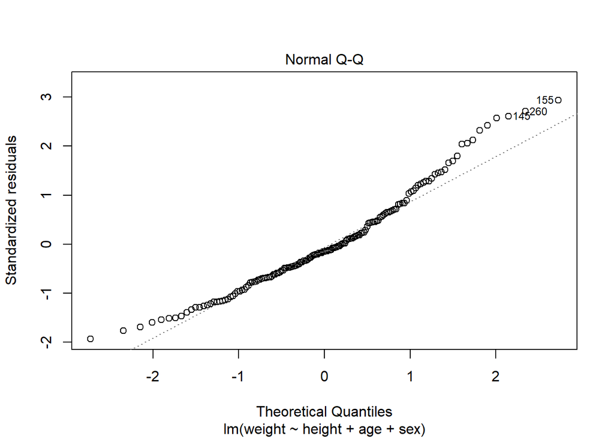

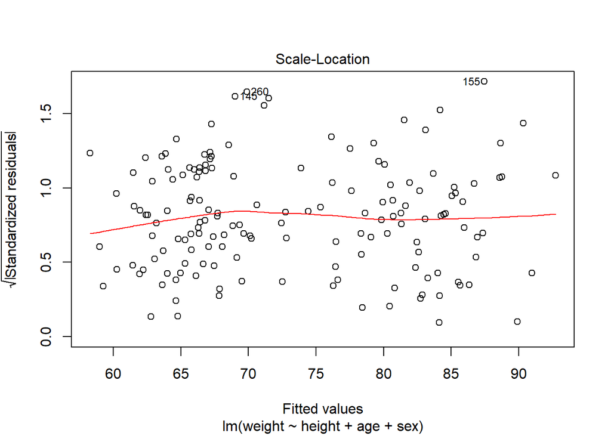

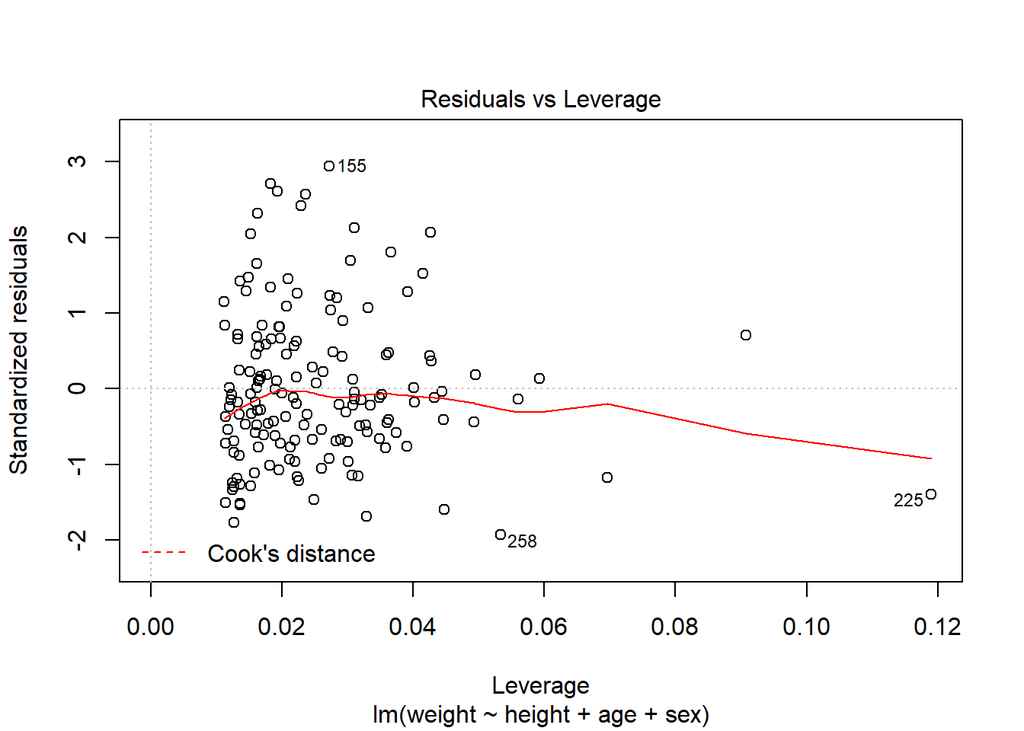

```r
plot(sex_model_nooutlier)
```

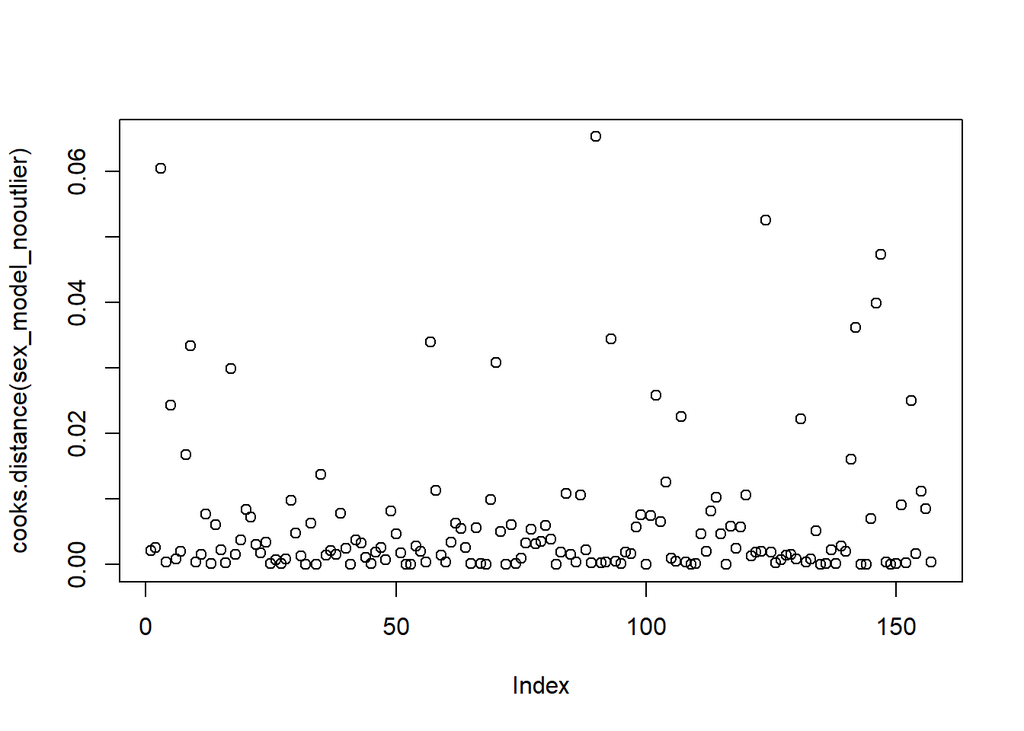

```r
plot(cooks.distance(sex_model_nooutlier))
```

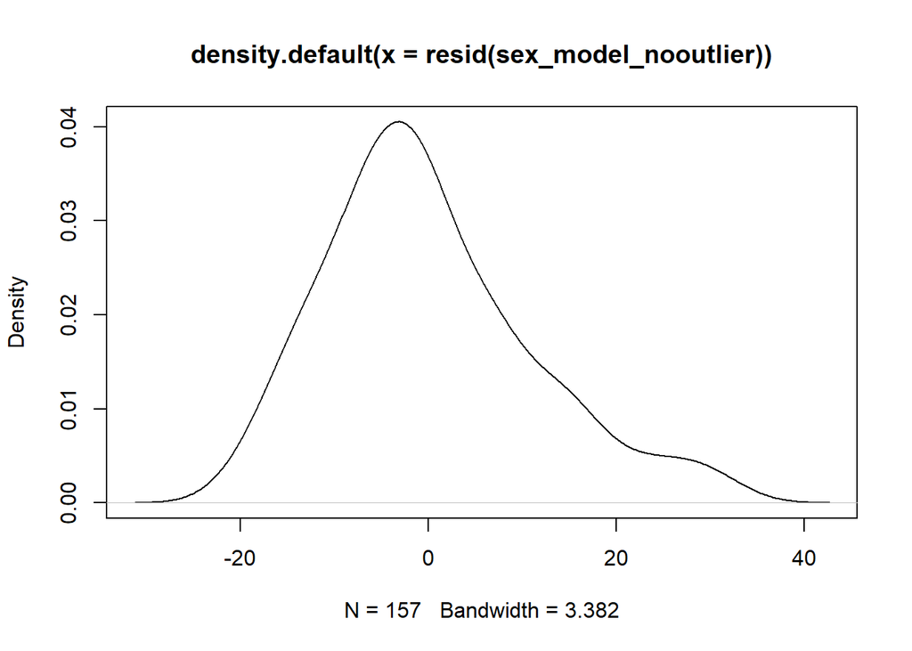

```r
plot(density(resid(sex_model_nooutlier)))
```

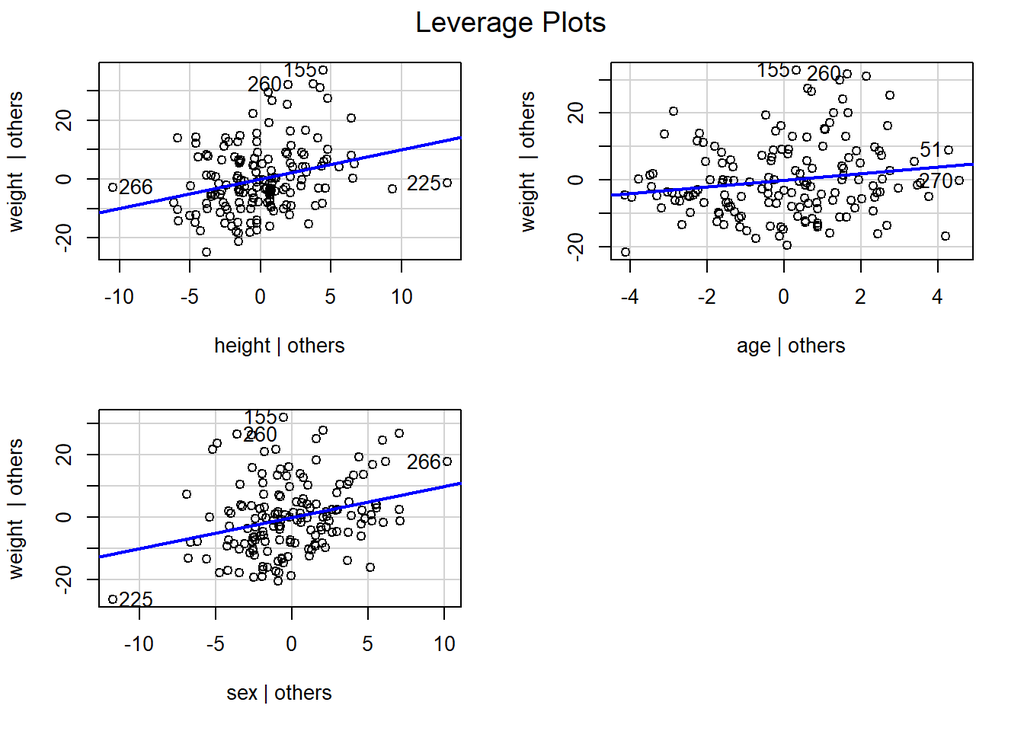

```r
leveragePlots(sex_model_nooutlier)
```

```r
# vif
vif(sex_model_nooutlier)
```

```
##   height      age      sex
## 2.016427 1.006734 2.016867
```

```r
#tolerance
1/vif(sex_model_nooutlier)
```

```
##    height       age       sex
## 0.4959266 0.9933106 0.4958186
```

**Outlier Model Comparisons**

```r
anova(base_model,sex_model)
```

```
## Analysis of Variance Table
##
## Model 1: weight ~ height + age
## Model 2: weight ~ height + age + sex
##   Res.Df   RSS Df Sum of Sq      F    Pr(>F)
## 1    155 26830
## 2    154 24684  1    2145.9 13.388 0.0003473 ***
## ---
## Signif. codes:  0 '***' 0.001 '**' 0.01 '*' 0.05 '.' 0.1 ' ' 1
```

## 3.4.1 Outlier Model Interpretatin

Our base model and Sex model were rebuilt without the outlier to investigate the difference. using dfbetas to investigate the change in the coefficients without the outlier, we noticed a large difference especially in the age coeffcient.

Reviewing the base model, we see the RSE has reduced from 13.16 with the outlier to 11.68 without, while the R-Squared has gone up from .319 to.341.

For our test dataset, our RMSE has reduced from 11.86 with the outlier to 11.78

Reviewing the sex model, we see the RSE has reduced from 12.66 with the outlier to 11.22 without, while the R-Squared has gone up from .373 to.396.

For our test dataset, our RMSE has reduced from 11.83 with the outlier to 11.73

A coefficient shows the change in our outcome variable given a unit of change in a predictor variable. we add these coefficients and the intercept to predict our outcome.

Remember, by removing the outlier our coefficients have changed. Our equations are now;

```
weight = -66.383 + 0.778(height) + 0.171(age)

weight = -14.175 +  0.449(height) + 0.162(age) + 9.564(sexMale)
```

An example with the mean height and age using the equations

```
-66.383 + 0.778 * (170.22) +  0.171 * (43.87) = 73.55
```

Using the mean height and age and male as example;

```
-14.175 + 0.449 * (170.22) +  0.162 * (43.87) + 9.564 * (1) = 78.92
```

Using the mean height and age and female as example;

```
-14.175 + 0.449 * (170.22) +  0.162 * (43.87) + 9.564 * (0) = 69.36
```

Testing the equation by substituting the mean values for our variables, we notice a slight change from the model with the outlier.

Analysis of the cooks distance plot after removing the outlier shows a lot of change, the distance between points is a lot more balanced as opposed to the outlier far off in the earlier models.

The diagnostic plots show better visualisation to prove the assumptions of linearity, normal distribution of residuals, homogeineity of varianve and non zero variance of predictors.

Examination for multicollinearity showed that the tolerance and variance influence factor measures where within acceptable levels (vif < 10; tolerance > 0.1)

# 4. Final Discussions

The aim of this paper was to build multiple linear regression models capable of predicting Weight better than just taking the mean. Initially, a relationship test between Weight and height showed a significant moderate postive relationship between them r=(.56), p<.05 with a covariance of 88.73, a relationship test between Weight and age showed a significant very weak postive relationship between them r=(.15), p<.05 with a covariance of 29.79. The test of difference between Weight and sex showed males had significantly higher levels of weight than females t(222)= -9.78, p < .05. Based on Cohen’s d. a large effect size .549 was found meaning, we should take care when using the difference.

Once the significant variables were identified our baseline model was built using height and age as the predictor variables. The model was significant and was capable of predicting approx. 32% of the variance in Weight, with all our predictors having a significant effect on the Weight.

For the 2nd model, the Sex model, Sex was added as a predictor to the baseline model after observing a significant difference between weight in males and females.

The Sex model was capable of predicting approx. 37% of the variance in Weight, with all our predictors having a significant effect on the Weight.

The models were relatively similar, but the effect of the sex coefficient added a new dynamic to the models. A coefficient is the value of change in our outcome variable given a unit of change in the predictor varialbe.

The base model and sex model (2nd model) were rebuilt without the outlier. both models reported better RSE and R-Squared values (11.68, 0.341) and (11.22, 0.396) respectively. The diagnosis plots were slightly better in meeting with assumptions of regression i.e linearity, equal variance, no overly influential points and normal distribution of errors.

inspecting the results of the dfbetas showed the age coefficient was most affected by removing the outlier.

Given the results in our model, a recollection of the data from the same sample to compare if any differences occur would be an interesting test. As new predictors could be discovered.

# 5. References

Australian Bureau of Statistics. (2018, September 28). Regional Population by Age and Sex, Australia, 2017. Australia.

Field, A., Miles, J., & Field, Z. (2012). Discovering Statistics Using R. London: SAGE Publications Ltd.

George, D., & Mallery, P. (2010). SPSS for Windows Step by Step: A Simple Guide and Reference 17.0 Update. 10th Edition. Boston: Pearson.

Johnson, E. O., Roth, T., & Breslau, N. (2006). The association of insomnia with anxiety disorders and depression: Exploration of the direction of risk. Journal of Psychiatric Research, 700-708.

Klerman, G. L. (2013). Anxiety and depression. In G. D. Burrows, Handbook of studies on depression (pp. 49-68). Amsterdam: Elsevier.

# 6. Appendix

```r
dfbetas(base_model)
```

```
##       (Intercept)        height           age
## 51   0.0023229992 -0.0046199130  1.194224e-02
## 190 -0.0448000112  0.0310873501  4.423715e-02
## 155 -0.3352636026  0.3435600319  2.661935e-02
## 46   0.0043413792  0.0025726783 -2.604401e-02
## 253  0.2193425329 -0.1934766313 -1.618065e-01
## 251  0.0097519517 -0.0116925057  1.262794e-02
## 35   0.0120507382 -0.0192109521  2.778132e-02
## 221 -0.0299394850  0.0285678326  1.752333e-02
## 145  0.0594577225 -0.0874134038  1.688626e-01
## 262 -0.0011790615  0.0012938443 -6.595054e-04
## 63   0.0644428116 -0.0461501361 -7.553730e-02
## 197  0.0073278664 -0.0294362790  7.134535e-02
## 47   0.0056301099 -0.0038722687 -7.281772e-03
## 105 -0.0865572771  0.1014992173 -4.969250e-02
```

[output cut: 144 more lines]

```r
dfbetas(sex_model)
```

```
##       (Intercept)        height           age       sexMale
## 51  -2.819556e-03 -2.902059e-03  4.716573e-02 -0.0138517667
## 190  3.506219e-03 -1.343155e-02  3.395330e-02  0.0439323922
## 155 -2.865954e-01  2.845943e-01  2.984011e-02 -0.0375541209
## 46  -2.231056e-02  1.900851e-02  2.242072e-02 -0.0288972644
## 253  1.684497e-01 -1.438072e-01 -1.674376e-01  0.0037268477
## 251  3.014373e-03 -4.723299e-03  2.459969e-02 -0.0154336736
## 35   1.780085e-03 -1.069277e-02  5.682654e-02 -0.0233798599
## 221 -1.802101e-01  1.809870e-01  4.982394e-02 -0.1866450302
## 145 -4.960249e-02  3.224929e-02  2.035468e-01 -0.1472845062
## 262 -3.158356e-02  3.327304e-02 -1.739807e-02 -0.0120064548
## 63   4.778196e-02 -3.480355e-02 -6.860152e-02  0.0075545495
## 197  8.244277e-02 -9.688792e-02  4.800532e-02  0.1150194212
## 47   1.004759e-03 -6.915533e-04 -1.662786e-03  0.0000973297
## 105 -6.862248e-02  7.746004e-02 -5.236823e-02 -0.0025715317
```

[output cut: 144 more lines]